# HOMEWORK 4

Duygu Kaya - IE582 - Fall 2020

## DATASET 4 : COVERTYPE DATASET

The aim of covertype dataset is predicting forest cover type from cartographic variables such as soil type, slope and wilderness area.There are 7 forest cover type, and the data consist class imbalance.In this context, many classification learning algorithms can have low predictive accuracy for the minority classes.Hence, downsampling method is used with caret package to overcome class imbalance issue.20000 instances are randomly selected duw to the computational issues.The data is already dummy-coding , there is no need any preprocessing.

- Multiclass Classification
- 54 attributes
- Class Imbalance
- 581012 instances
- Numerical features

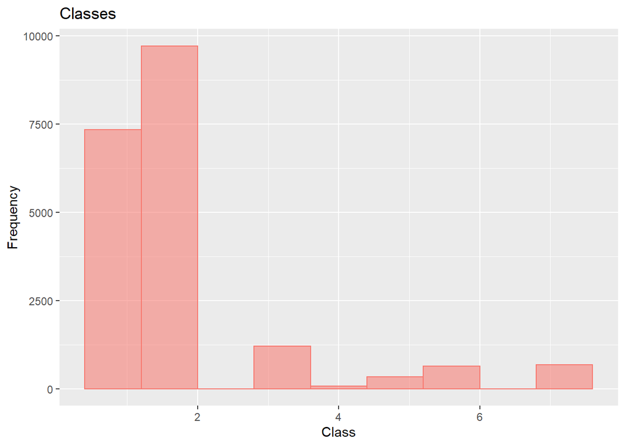

```r
# HOMEWORK 4/PART 4

library(tidyverse)
library(dplyr)
library(stringr)
library(glmnet)
library(stats)
library(base)
library(caret)
library(rpart)
library(rattle)
library(readxl)
library(Metrics)
library(penalized)
library(randomForest)
library(gbm)
library(plyr)
library(ggplot2)
library(DMwR)

# COVERTYPE DATASET
covertype <- read.table("C:\\Users\\kayad\\Desktop\\covtype.data.gz",sep = ",")
covertype <- covertype[sample(nrow(covertype), 20000), ]
colnames(covertype)[colnames(covertype) == "V55"] <- "class"
covertype <- subset(covertype,select=-c(V21,V29,V39,V48))

qplot(covertype$class,geom="histogram",binwidth = 0.8, main = "Classes", xlab = "Class",  ylab = "Frequency",col = "red", fill ="red", alpha=0.3)+theme(legend.position = "none")
```

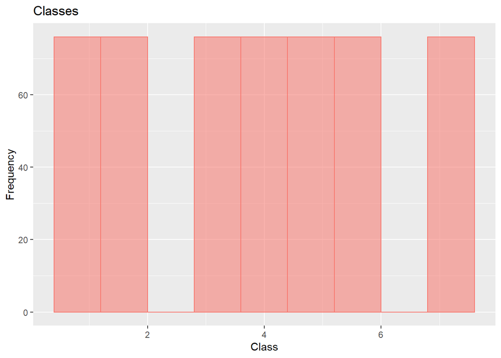

```r
covertype$class <- as.factor(as.character(covertype$class))
covertype_balanced <-caret::downSample(covertype, covertype$class)
covertype_balanced$class <- as.numeric(as.character(covertype_balanced$class))
qplot(covertype_balanced$class,geom="histogram",binwidth = 0.8, main = "Classes", xlab = "Class",  ylab = "Frequency",col = "red", fill ="red", alpha=0.3)+theme(legend.position = "none")
```

```r
# train and test data

# 80% of the sample size
smp_size <- floor(0.8 * nrow(covertype_balanced))

set.seed(123)
train_ind <- sample(seq_len(nrow(covertype_balanced)), size = smp_size)

covertype_training <-covertype_balanced[train_ind, ]
covertype_test <- covertype_balanced[-train_ind, ]

# cv data

covertype_training<-covertype_training[sample(nrow(covertype_training)),]

folds <- cut(seq(1,nrow(covertype_training)),breaks=10,labels=FALSE)
for(i in 1:10){
  testIndexes <- which(folds==i,arr.ind=TRUE)
  covertype_cv <- covertype_training[testIndexes, ]
  covertype_train <- covertype_training[-testIndexes, ]
}
```

### PENALIZED REGRESSION APPROACH

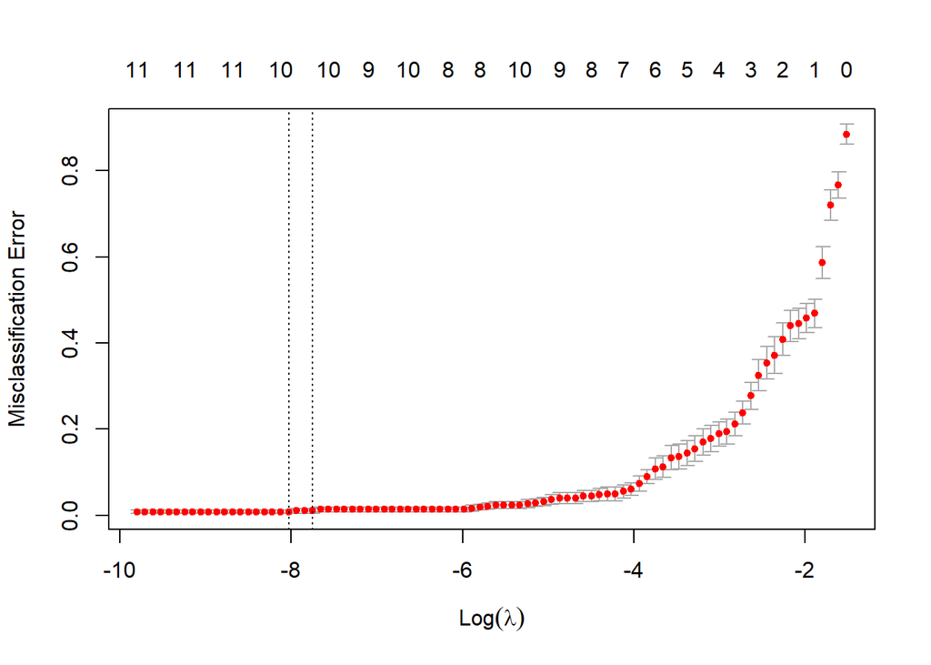

```r
# PENALIZED REGRESSION METHOD
covertype$class <- as.factor(as.character(covertype$class))
class  <- as.factor(covertype_train$class)
class2 <- as.factor(covertype_test$class)
class3 <- as.factor(covertype_cv$class)
class  <- as.matrix(class)
class2 <- as.matrix(class2)
class3 <- as.matrix(class3)
covertype_train_lasso <- covertype_train[,1:51]
covertype_train_lasso <- as.matrix(covertype_train_lasso )
covertype_test_lasso <- covertype_test[,1:51]
covertype_test_lasso <- as.matrix(covertype_test_lasso )
covertype_cv_lasso <- covertype_cv[,1:51]
covertype_cv_lasso <- as.matrix(covertype_cv_lasso )


cv_covertype<- cv.glmnet(covertype_train_lasso, class, type.measure = "class" ,family = "multinomial")
lambda_min <- cv_covertype$lambda.min
plot(cv_covertype)
```

```r
lasso1 <- glmnet(covertype_train_lasso,covertype_train$class, type.measure = "class" ,family = "multinomial",lambda = 0.1)
predict1<- predict(lasso1,covertype_test_lasso, type="class")
predict_cv1 <- predict(lasso1,covertype_cv_lasso,type="class")
table1 <- table(class2,predict1)
error_test1= 1-sum(diag(table1))/nrow(covertype_test)
error_test1
```

```
## [1] 0.3551402
```

### DECISION TREE APPROACH

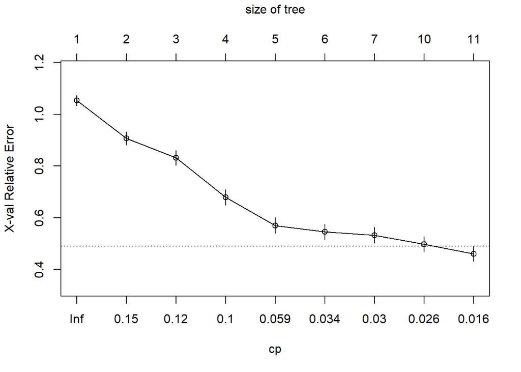

```r
covertype_train_DT <- covertype_train[,1:51]
covertype_train_DT <- cbind(class,covertype_train_DT)
covertype_test_DT <- covertype_test[,1:51]
covertype_cv_DT <- covertype_cv[,1:51]

cla_tree_1 = rpart(class~.,data = covertype_train_DT,method = 'class')

plotcp(cla_tree_1)
```

```r
printcp(cla_tree_1)
```

```
##
## Classification tree:
## rpart(formula = class ~ ., data = covertype_train_DT, method = "class")
##
## Variables actually used in tree construction:
## [1] V1  V10 V13 V3  V4  V5  V7
##
## Root node error: 321/382 = 0.84031
##
## n= 382
##
##         CP nsplit rel error  xerror     xstd
## 1 0.152648      0   1.00000 1.05296 0.019438
## 2 0.140187      1   0.84735 0.90654 0.025938
## 3 0.109034      2   0.70717 0.83178 0.027930
## 4 0.093458      3   0.59813 0.67913 0.030138
## 5 0.037383      4   0.50467 0.57009 0.030417
## 6 0.031153      5   0.46729 0.54517 0.030337
## 7 0.028037      6   0.43614 0.53271 0.030276
## 8 0.024922      9   0.35202 0.49844 0.030040
## 9 0.010000     10   0.32710 0.46106 0.029662
```

```r
cla_tree_1$variable.importance
```

```
##          V1         V14          V6         V10          V3          V7
## 114.7205834  45.7265991  38.3441685  31.2081116  21.6131017  20.3109893
##         V24          V4          V5         V13          V9         V17
##  16.1319634  13.3780402  12.9844143  11.7035573  11.3269786   8.8942830
##         V18         V54         V52         V53          V2          V8
##   7.5102077   6.4393204   5.9439881   5.9439881   4.5663086   3.6534935
##         V12         V36         V37         V28         V26         V43
##   3.4673264   3.4162702   1.7081351   1.2426475   1.2385766   0.9803433
##         V20         V31
##   0.9673110   0.8284317
```

```r
error_DT<-c()
error_cv_DT<-c()
DT_TABLE<- matrix(0,4,12)
cp <- c(0.001,0.005,0.01)
minsplit <- c(5,10,15,20)


i=1
for(k in 1:length(minsplit)){
  for(l in 1:length(cp)){
    cla_tree <- rpart(class~.,data = covertype_train_DT, method='class', control = rpart.control(cp = cp[l],minsplit = minsplit[k]))
    cla_tree_cv <- rpart(class~.,data = covertype_train_DT, method='class', control = rpart.control(cp = cp[l],minsplit = minsplit[k]))
    testp <-predict(cla_tree, covertype_test_DT, type = 'class')
    cv_p  <- predict(cla_tree_cv, covertype_cv_DT, type = 'class')
    cv_pred <- as.factor(as.character(cv_p))
    test_pred <- as.factor(as.character(testp))
    table_test <- table(class2,test_pred)
    table_cv <- table(class3,cv_pred)
    error_cv_DT[i]<-1-sum(diag(table_cv))/nrow(covertype_cv)
    error_DT[i] <- 1-sum(diag(table_test))/nrow(covertype_test)
    i = i+1
    DT_TABLE <- cbind(error_DT,error_cv_DT, minsplit,cp)
  }
}
DT_TABLE
```

```
##        error_DT error_cv_DT minsplit    cp
##  [1,] 0.4205607   0.3255814        5 0.001
##  [2,] 0.4392523   0.3255814       10 0.005
##  [3,] 0.4018692   0.3488372       15 0.010
##  [4,] 0.4112150   0.3023256       20 0.001
##  [5,] 0.4018692   0.3255814        5 0.005
##  [6,] 0.4018692   0.3488372       10 0.010
##  [7,] 0.4205607   0.3255814       15 0.001
##  [8,] 0.4018692   0.3255814       20 0.005
##  [9,] 0.4018692   0.3488372        5 0.010
## [10,] 0.4018692   0.3488372       10 0.001
## [11,] 0.3925234   0.3255814       15 0.005
## [12,] 0.4018692   0.3255814       20 0.010
```